# Prediction Model on Exercise Data

Pavan Malladi

September 27, 2015

# Synopsis

The data for this project come from this source: http://groupware.les.inf.puc-rio.br/har. We use data from accelerometers on the belt, forearm, arm, and dumbell of 6 participants who were asked to perform barbell lifts correctly and incorrectly in 5 different ways.

We fit a model to understand how the data classifies into various classes and then use the model to predict new data.

# Data Preparation

Read the testing and training datasets.

We eliminate columns that do not consistently have any valuable information

```r
good_cols <- colSums(is.na(ts_full))/nrow(ts_full) < 0.1
tr_cln <- tr_full[,good_cols]
ts_cln <- ts_full[,good_cols]
```

In our case, the most valuable information is in numeric form. So, extract numeric columns.

```r
numeric_cols <- sapply(tr_cln, is.numeric)
tr_cln <- tr_cln[, numeric_cols]
ts_cln <- ts_cln[,numeric_cols]
```

The above step would have eliminated the “target” variable as well. Add it back.

```r
tr_cln <- mutate(tr_cln, classe = tr_full[,ncol(tr_full)])
ts_cln <- mutate(ts_cln, classe = ts_full[,ncol(ts_full)])
```

Get rid of timestamp columns that do not hold much information in our case.

```r
timestamp_cols <- c(1,2)
tr_cln <- tr_cln[,-timestamp_cols]
ts_cln <- ts_cln[,-timestamp_cols]
```

Model can be simplified by eliminating highly correlated columns/predictors.

```r
highCorr <- findCorrelation(cor(tr_cln[,-ncol(tr_cln)]), 0.90)
tr_cln <- tr_cln[,-highCorr]
ts_cln <- ts_cln[,-highCorr]
```

Let us now split the data for Training and Cross-validation purposes. This allows us to verify how good our model works

```r
set.seed(1)
forTrain <- createDataPartition(tr_cln[,ncol(tr_cln)], p = 0.75, list = FALSE)
tr_train <- tr_cln[forTrain,]
tr_crossValid  <- tr_cln[-forTrain,]
```

In order to determine the optimal number of variables that should be used in our prediction model, we determine mtry value using tuneRF function. The predictors and target values are passed as parameters along with a few other tuning parameters. The variable count that gives the minimum out-of-B error is the value we should use for “mtry” parameter in the randomForest function for prediction.

```
## mtry = 6  OOB error = 0.25%
## Searching left ...
## mtry = 4     OOB error = 0.29%
## -0.1621622 0.01
## Searching right ...
## mtry = 9     OOB error = 0.2%
## 0.2162162 0.01
## mtry = 13    OOB error = 0.18%
## 0.1034483 0.01
## mtry = 19    OOB error = 0.16%
## 0.07692308 0.01
## mtry = 28    OOB error = 0.22%
## -0.3333333 0.01
```

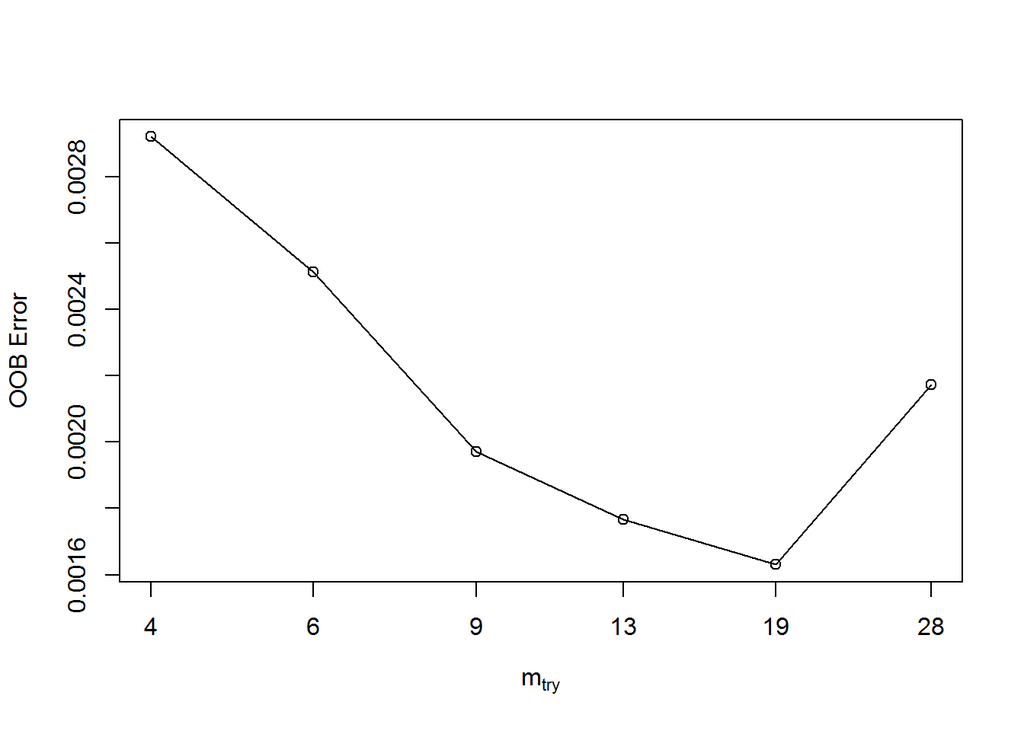

```r
mtryV <- tuneRF(tr_train[,-ncol(tr_train)],tr_train[,ncol(tr_train)],ntreeTry = 200, stepFactor = 1.5, improve = 0.01, trace=TRUE,plot=TRUE,dobest = FALSE)
```

# Prediction Model for our Training Data

Using the randomForest function, fit a prediction model for our training data.

```r
rfFit <- randomForest(classe~.,data=tr_train,mtry=apply(mtryV,2,which.min)[2],ntree=200,keep.forest = TRUE, importance=TRUE, crossValid = tr_crossValid)
predcrossValid <- predict(rfFit, newdata = tr_crossValid)
```

Confusion Matrix between the actual and predicted values for cross-validation data

```r
confusionMatrix(predcrossValid, tr_crossValid$classe)
```

```
## Confusion Matrix and Statistics
##
##           Reference
## Prediction    A    B    C    D    E
##          A 1395    3    0    0    0
##          B    0  945    2    0    0
##          C    0    1  852    5    0
##          D    0    0    1  798    0
##          E    0    0    0    1  901
##
## Overall Statistics
##
##                Accuracy : 0.9973
##                  95% CI : (0.9955, 0.9986)
##     No Information Rate : 0.2845
##     P-Value [Acc > NIR] : < 2.2e-16
##
##                   Kappa : 0.9966
##  Mcnemar's Test P-Value : NA
##
## Statistics by Class:
##
##                      Class: A Class: B Class: C Class: D Class: E
## Sensitivity            1.0000   0.9958   0.9965   0.9925   1.0000
## Specificity            0.9991   0.9995   0.9985   0.9998   0.9998
## Pos Pred Value         0.9979   0.9979   0.9930   0.9987   0.9989
## Neg Pred Value         1.0000   0.9990   0.9993   0.9985   1.0000
## Prevalence             0.2845   0.1935   0.1743   0.1639   0.1837
## Detection Rate         0.2845   0.1927   0.1737   0.1627   0.1837
## Detection Prevalence   0.2851   0.1931   0.1750   0.1629   0.1839
## Balanced Accuracy      0.9996   0.9976   0.9975   0.9961   0.9999
```

# Prediction for Test Data

We can now predict the outcome for Test data

```r
predTest <- predict(rfFit, newdata = ts_cln)
predTest
```

```
##  1  2  3  4  5  6  7  8  9 10 11 12 13 14 15 16 17 18 19 20
##  B  A  B  A  A  E  D  B  A  A  B  C  B  A  E  E  A  B  B  B
## Levels: A B C D E
```

# Expected Out of Sample Error

The expected out of sample (or OOB) error is the OOB computed by tuneRF for the mtry value that was used in final randomForest function. And the value is:

```
## [1] 0.001630656
```

# Plots

Plot of important variables in the Model

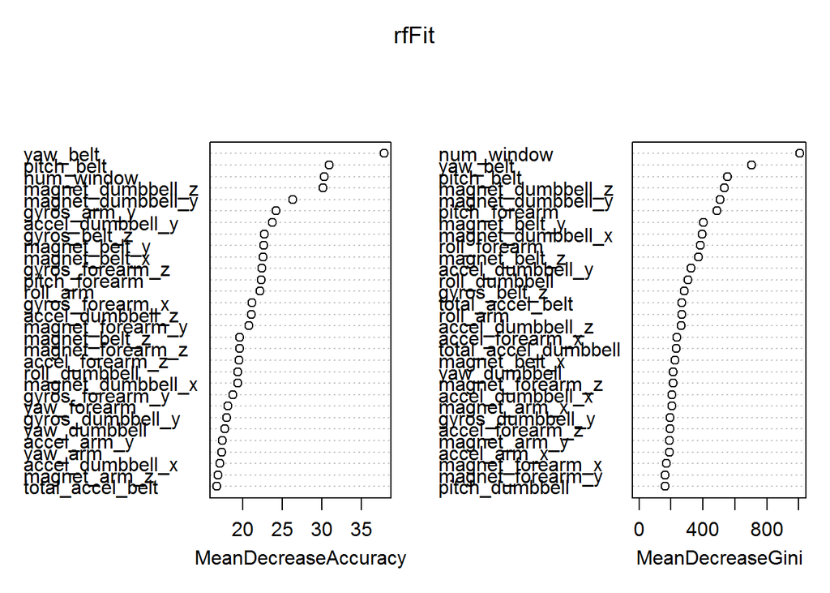

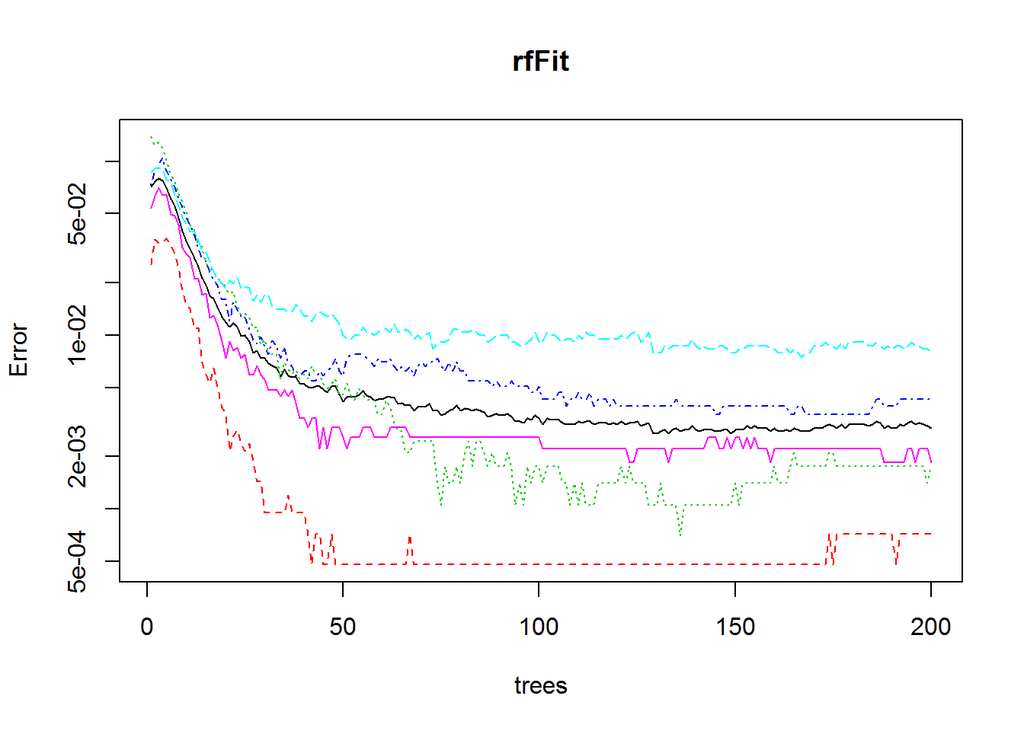